# Analyses_August2021

Ana Miller-ter Kuile

8/9/2021

Thanks so much for agreeing to help with this project! I honestly have no idea as to the level (“quality/novelty”) of this project but I think it could be a good fit for a specific journal (e.g. Food Webs) or a mid-tier ecology journal (Biology Letters)? Anyway - as you look at the data maybe you can provide some insight on how to write this and for where!

# The questions

This project would be building off previous work on Palmyra examining how ecosystem productivity and size influences food chain length using stable isotopes (Young et al. 2013). That study found that islet productivity (driven by seabird nutrient additions) shaped food chain length while islet size did not. The factors of islet size and productivity do not covary in this system.

What we can add with this dataset is some idea of the mechanisms by which food chain length increases because we have several datasets for those same top predators from that study (*Heteropoda venatoria*) at the individual level, including stable isotope values ($\delta^{15}N$ and $\delta^{13}C$), body size, and diet DNA metabarcoding data for a subset of individuals.

I think the supplement from the 2013 paper provides a really nice visual of some of the mechanisms I think we can now try to answer, in part.

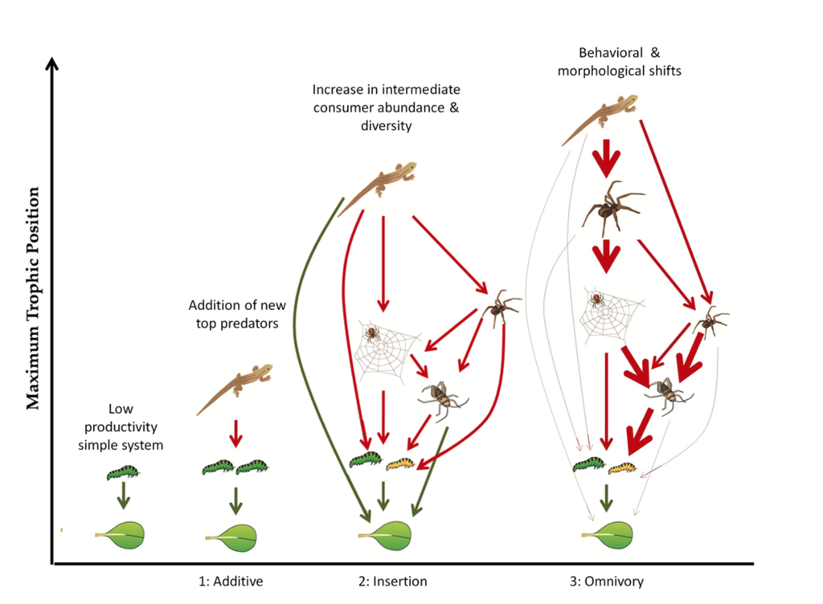

Specifically, we can both add to the 2013 paper’s thoughts on food chain length and broaden that to isotopic niche space (Layman et al. 2012) and ask:

1. **Does islet productivity shift isotopic niche space** (dataset: top predator isotope values)?

```
- If so, is this merely a shift up and down (mirroring the shifts in food chain length already observed) OR an expansion among individuals from the same environment, suggesting that in addition to eating higher on the food chain, top predators are also eating a broader variety of food items.
```

Once we have answered that question, we can use some other datasets to ask some add-on questions about the mechanisms driving shifts in food chain length and/or isotopic niche space. These include:

2. **Mechanism One** *(“Top Predators Choose New Food”)*: Does islet productivity correspond to different top predator prey communities (dataset: top predator diet DNA metabarcoding data)
3. **Mechanism Two** *(“Bigger Top Predators”)*: Does islet productivity drive increases in top predator size, suggesting that increased resources allow predators to get to a size where they can access more resources, even if these just include the same prey at a larger body size. (dataset: top predator body size values)

```
- (and tangentially, do larger predators have higher trophic positions based on $\delta^{15}N$ values?)
```

4. **Mechanism Three** *(“Top Predator Prey Get More Predatory”)*: Do prey items shift their isotope values along the islet productivity, suggesting that lower trophic levels are shift with productivity, inflating top predator trophic values? (dataset: prey item isotope values)

*An aside and/or alternative framing: H. venatoria is an introduced predator species and so the framing/conclusions could be shaped by the species characteristics (e.g. diet/habitat generalism) that have allowed this species to be successful in new environments.*

# The data

As I mentioned above, we have multiple datasets to use for this project:

1. Stable isotope data ($\delta^{15}N$ and $\delta^{13}C$) from 160 predator individuals from three separate sampling years (2009, 2012, and 2015) across 12 islets (6 high, 6 low productivity; 6 big, 6 small in area)
2. Body size data (length and mass) for these same predator individuals
3. DNA diet data (at Order level, so we could have more data) from 34 individuals (all from 2015) constituting 68 predator-prey pairs from five islets (3 high, 2 low productivity; 3 big, 2 small in area)
4. Stable isotope data ($\delta^{15}N$ and $\delta^{13}C$) from islet-level pooled samples of six prey orders detected in DNA diet (197 pooled samples total).

Several of you helped collect these spiders, but for context: We collected these spiders opportunistically at night using eye shine. They represent the first 10-15 individuals observed on each islet during each sampling period. Importantly, as a result, while they do not represent the full size range of this species, they do represent the size distribution of those individuals of this species that are actively hunting in a similar habitat. (The juveniles of this species, just anecdotally, are often found in the canopy so there could be some really cool stage structure habitat partitioning for this species, but that’s another project that we can’t approach with the current dataset…)

## 1. Does islet productivity shift isotopic niche space?

We could think that higher productivity would allow predator populations to have greater individual variation, such that each individual was able to establish a more distinct isotopic niche in a more productive environment. However, though we observe a clear distinction in isotopic trophic level (measured by $\delta^{15}N$) values, see Young et al. 2013 as well) and a shift in $\delta^{13}C$ (a more ‘terrestrial’ signature on higher productivity islets), we do not see a clear shift in the isotopic niche space occupied by top predators on high versus low productivity habitat patches.

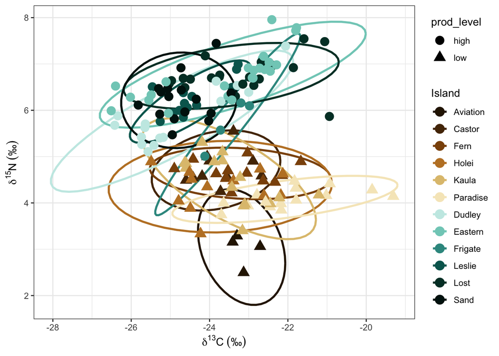

Those isotopic niche areas measured:

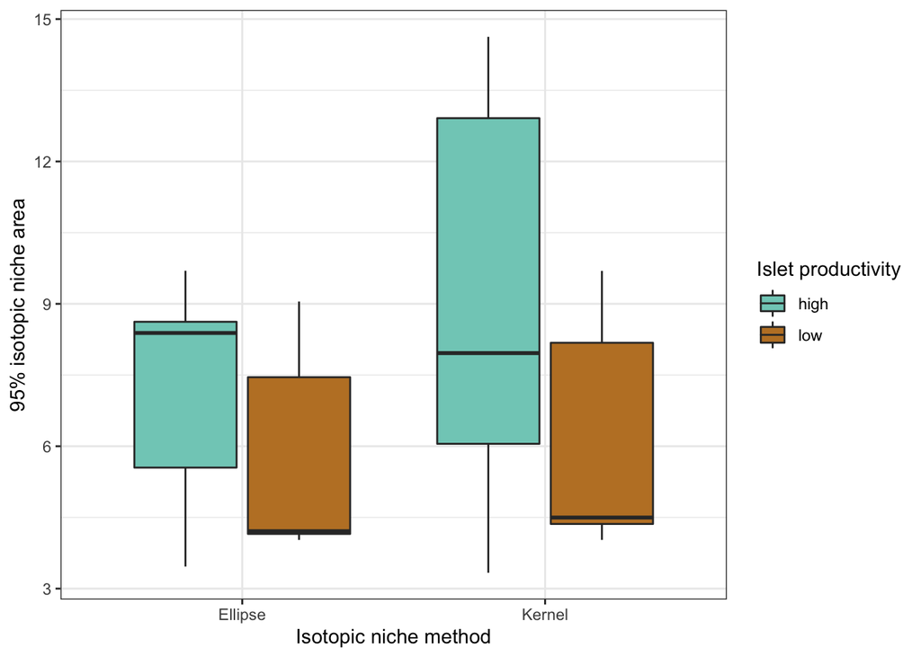

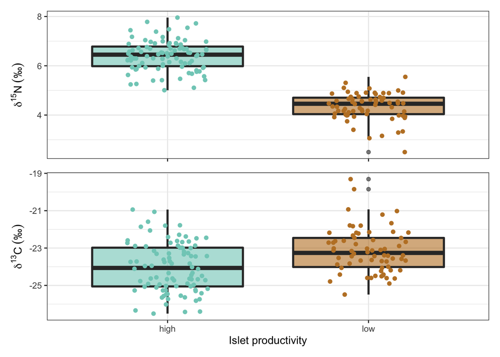

### 1. Conclusions

Top predators increase their trophic positions (measured by $\delta^{15}N$) and the base of their resources (measured by $\delta^{13}C$), but don’t seem to be broadening their isotopic niche space (variety of resources). We would then assume that predators are eating higher on the food chain on high-productivity islets, and perhaps more terrestrially, and then the question becomes: what allows them to do so?

## 2. Mechanism One: “Top Predators Choose New Food”

The most straightforward mechanism of why top predators are higher on the food chain is that they are choosing new food items in higher-resource environments. Given that their niche space shifts upward but does not expand, we would expect this to perhaps look like a complete shift from one prey community to another, such that their prey become more predatory themselves on high-productivity islets.

When we look at diet DNA metabarcoding data from these predator individuals, we see that there is no clear difference in their diets across high versus low productivity environment (PERMANOVA based on Bray-Curtis dissimilarity, p-value = 0.3)

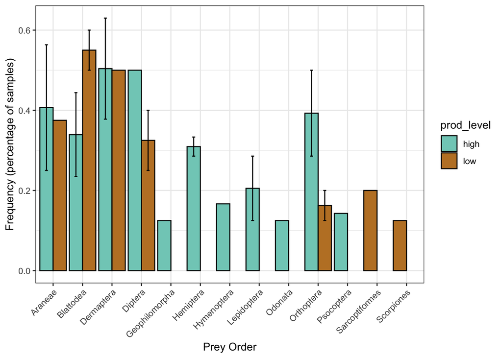

### 2. Conclusions

What it seems like is that predators are not really shifting their diets much across environmental contexts. Could this be, then, that predators are either getting bigger and so possibly eating bigger (maybe higher trophic position) prey of the same species (**Mechanism Two**, below), or, that the prey items themselves are becoming higher trophic position in higher resource environments. So, the expansion of the food chain is happening somewhere before the top predators get into the scene with increased omnivory at intermediate trophic levels (**Mechanism Three**, below).

## 3. Mechanism Two: “Bigger Top Predators”

Another mechanism of change in top predator trophic position may be that top predators are getting larger when there are more resources, and thus, able to consume larger individuals of the same prey items that themselves are higher on the food chain.

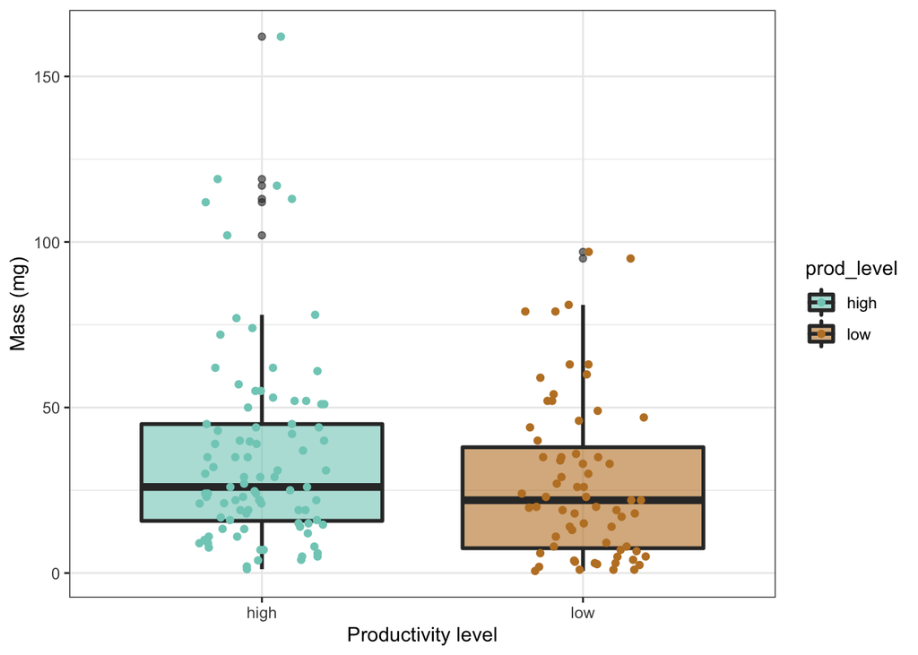

However, we find no clear difference in mass of individuals across habitat productivity.

Furthermore, there is no clear evidence that larger individuals even are higher on the food chain:

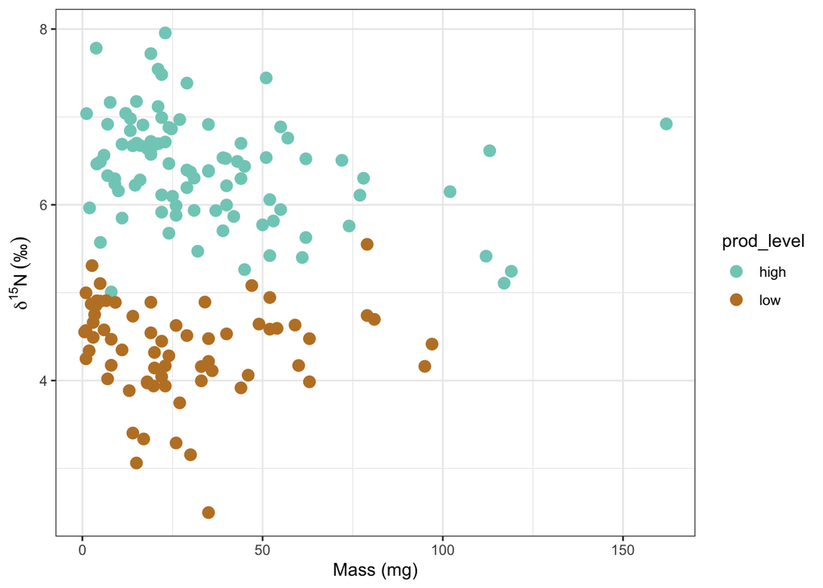

### 3. Conclusions

There seems to be no clear evidence that top predators are reaching larger sizes (or that size is even correlated to trophic position) in higher resource environments.

## 4. Mechanism Three: “Top Predator Prey Get More Predatory”

The final mechanism could be that while top predators continue to eat the same prey source, that prey source has become more omnivorous - driving increases in food chain length in the intermediate/middle of the food chain as opposed to the top of the food chain. What we see is a clear increase in prey trophic position (based on $\delta^{15}CN$) in more productive environments, suggesting that increases in food chain length are happening due to increased omnivory in the middle of the food chain as opposed to increased consumption of other predators at the top of the food chain.

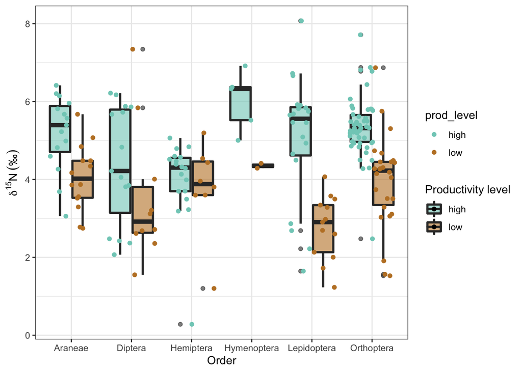

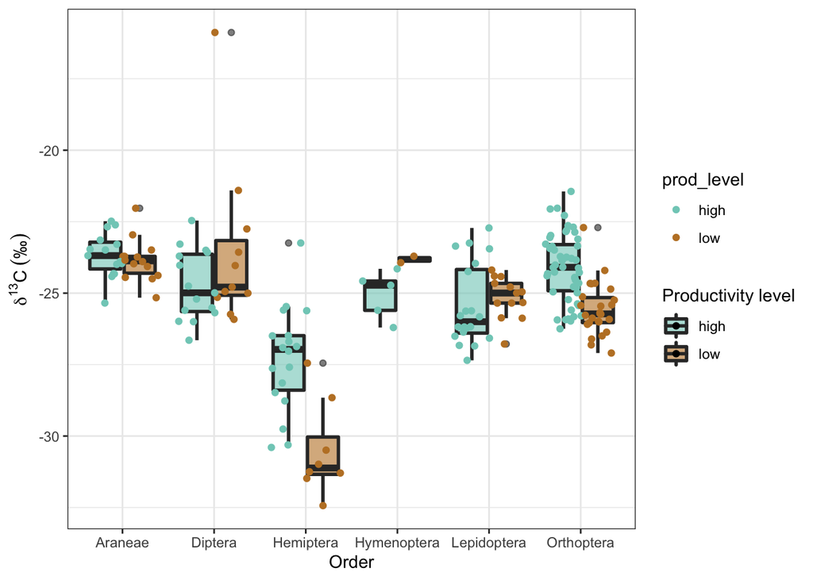

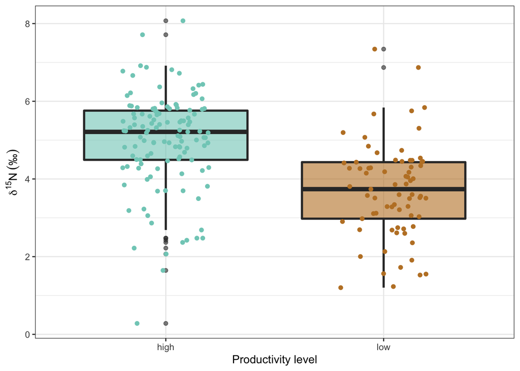

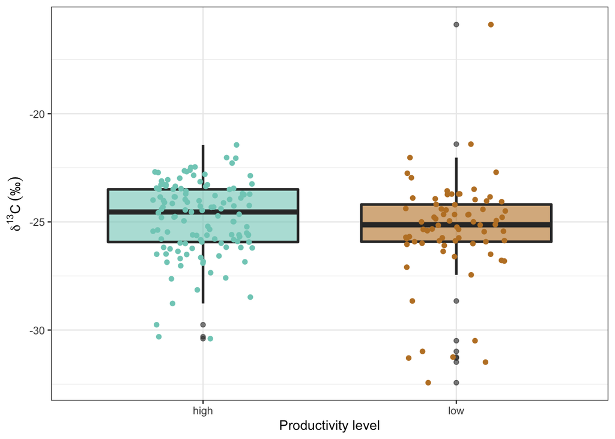

### 4. Conclusions

This final mechanism seems to have the most promising evidence, suggesting that food chain lengths grow in the middle in this environment, as opposed to at the top. In addition, these findings suggest that prey are shifting their food sources, as opposed to top predators.

# Why do we care?

I don’t know!

# References and relevant papers I like

Eckrich, C. A., Albeke, S. E., Flaherty, E. A., Bowyer, R. T., & Ben-David, M. (2020). rKIN: Kernel-based method for estimating isotopic niche size and overlap. Journal of Animal Ecology, 89(3), 757–771. [doi: 10.1111/1365-2656.13159](https://besjournals.onlinelibrary.wiley.com/doi/abs/10.1111/1365-2656.13159)

- Newest methods in determining isotopic niche space.

Eitzinger, B., Abrego, N., Gravel, D., Huotari, T., Vesterinen, E. J., & Roslin, T. (2019). Assessing changes in arthropod predator–prey interactions through DNA-based gut content analysis—variable environment, stable diet. Molecular Ecology, 28(2), 266–280. [doi: 10.1111/mec.14872](https://onlinelibrary.wiley.com/doi/abs/10.1111/mec.14872)

- Documented diet of a spider using DNA across environments, showing that composition stayed the same despite very different environmental conditions.

Kennedy, S., Lim, J. Y., Clavel, J., Krehenwinkel, H., & Gillespie, R. G. (2019). Spider webs, stable isotopes and molecular gut content analysis: Multiple lines of evidence support trophic niche differentiation in a community of Hawaiian spiders. Functional Ecology, 33(9), 1722–1733. [doi: 10.1111/1365-2435.13361](https://besjournals.onlinelibrary.wiley.com/doi/abs/10.1111/1365-2435.13361)

- Looked at a radiation of *Tetragnatha* (genus) spiders in Hawai’i where half of the species have a different hunting strategy from the other half and showed cool shifts in isotope and DNA diet (at Order leve) across these two halves of the clade.

Layman, C. A., Araujo, M. S., Boucek, R., Hammerschlag-Peyer, C. M., Harrison, E., Jud, Z. R., … Bearhop, S. (2012). Applying stable isotopes to examine food-web structure: An overview of analytical tools. Biological Reviews, 87(3), 545–562. [doi: 10.1111/j.1469-185X.2011.00208.x](https://onlinelibrary.wiley.com/doi/abs/10.1111/j.1469-185X.2011.00208.x)

- The foundational isotopic niche space paper, though I think the rKIN methods are a bit more relevant now.

Nigro, K. M., Hathaway, S. A., Wegmann, A. S., Miller-ter Kuile, A., Fisher, R. N., & Young, H. S. (2017). Stable isotope analysis as an early monitoring tool for community-scale effects of rat eradication. Restoration Ecology, 25(6), 1015–1025. [doi: 10.1111/rec.12511](https://onlinelibrary.wiley.com/doi/abs/10.1111/rec.12511)

- A paper from Palmyra on land crab isotope shifts pre-post rat eradication.

Young, H. S., McCauley, D. J., Dunbar, R. B., Hutson, M. S., Ter-Kuile, A. M., & Dirzo, R. (2013). The roles of productivity and ecosystem size in determining food chain length in tropical terrestrial ecosystems. Ecology, 94(3), 692–701. [doi: 10.1890/12-0729.1](https://esajournals.onlinelibrary.wiley.com/doi/abs/10.1890/12-0729.1)

- The paper from Palmyra showing shifts in trophic position of predators using stable isotopes with increased islet productivity, but not islet size. This paper used an pooled value of each predator species per islet rather than individual-level diet or isotope data.